# Chapter 9 - Support Vector Machines - Conceptual Exercises

Greg Foletta

## 1

**This problem involves hyperplanes in two dimensions.**

### a)

**Sketch the hyperplane* $1 + 3X_1 - X_2 = 0$. *Indicate the set of points for which the formula is* $ < 0 $*and the set for which it is *$> 0$*.**

We let $X_1$ be on the x-axis and $X_2$ be on the y-axis. We move $X_2$ around so we have $X_2 = 3_X1 + 1$.

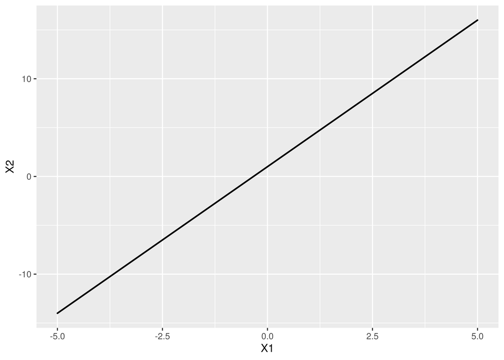

```r
tibble(X1 = seq(-5, 5, .01), X2 = 3 * X1 + 1) %>%
    ggplot(aes(X1, X2)) +
    geom_point(size = .1)
```

The set set of points above the line are when the formula is $< 0$, and the set of points above the line are when the formula $< 0$.

### b)

*On the same plot, sketch the hyperplane $-2 + X_1 + 2X_2 = 0$.

Moving $X_2$ around we have $X_2 = 2 - \frac{X_1}{2}$

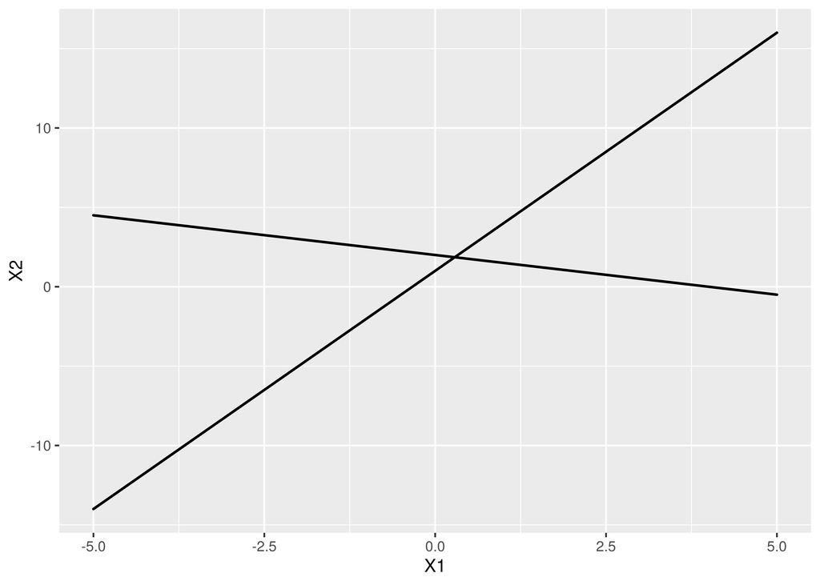

```r
tibble(
    X1 = seq(-5, 5, .01),
    X2 = 3 * X1 + 1,
    X2A = 2 - X1/2) %>%
    ggplot() +
    geom_point(aes(X1, X2), size = .1) +
    geom_point(aes(X1, X2A), size = .1)
```

The points above the line are when the formula is $> 0$ and the points below this line are when the formula is $< 0$.

## 2)

*We have seen that in $p = 2$ dimensions, a linear decision boundary takes the form $\beta_0 + \beta_1X_1 + \beta_2X_2 = 0$. We now investigate a non-linear decison boundary.

### a)

*Sketch the curve $(1 + X_1)^2 + (2 - X_2)^2 = 4$.

The formula is for a circle with radius 2 ($\sqrt{4}$) and the centre being at $(-1, 2)$.

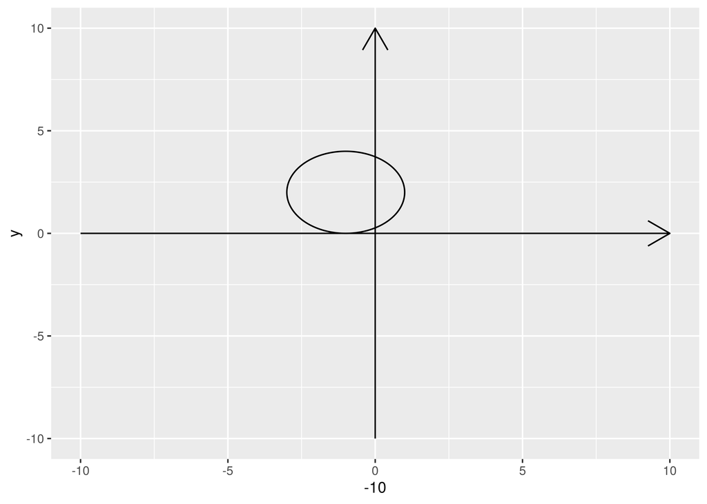

```r
library(ggforce)
ggplot() +
    geom_segment(aes(x = -10, y = 0, xend = 10, yend = 0), arrow = arrow()) +
    geom_segment(aes(x = 0, y = -10, xend = 0, yend = 10), arrow = arrow()) +
    geom_circle(aes(x0 = -1, y0 = 2, r = 2))
```

### b)

**Indicates the points that are $> 4$ and those which are $\le 4$.**

The points inside and on the line of the circle are $le 4$ and those outside of the circle are $> 4$.

### c)

**Suppose that a classifier assigns an observation to the blue class if it’s $> 4$ and to the red class otherwise. To what class are the following observations classified to:**

```r
classifier <- function(x) {
    sum <- (1 + x[1])^2 + (2 - x[2])^2
    return( ifelse(sum <= 4, "red", "blue") )
}
```

- (0, 0)
- (-1, 1)
- (2, 2)
- (3, 8)

```r
list(
    c(0,0),
    c(-1,1),
    c(2,2),
    c(3,8)
) %>% map_chr(~classifier(.x))
```

```
## [1] "blue" "red"  "blue" "blue"
```

### d)

**Argue that while the decision boundary is not linear in terms of $X_1, X_2$, it is linear in terms of $X_1^2, X_2^2$.**

We are enlarging the feature space with functions of the original features. The function in this case is a quadratic function. In this enlarged feature space the decision boundary is in fact linear: if we expand out the terms we end up with:

$$ (1 + 2X_1 + X_2^2) + (4 - 4X_2 + X_2^2) =

5 + 2X_1 + 4X_2 + X_1^2 + X_2^2 $$ However in the original feature space, the decision boundary is in the form of a quadratic: not linear.

## 3)

**We explaore the maximial margin classifier on a toy set**

### a)

*We are given $n = 7$ and $p = 2$ dimensions. For each observation there is an associated class label.

```r
data_3a <- tibble(
    obs = 1:7,
    X1 = c(3,2,4,1,2,4,4),
    X2 = c(4,2,4,4,1,3,1),
    Y = as.factor(c('Red', 'Red', 'Red', 'Red', 'Blue', 'Blue', 'Blue'))
)
```

Sketch the observations:

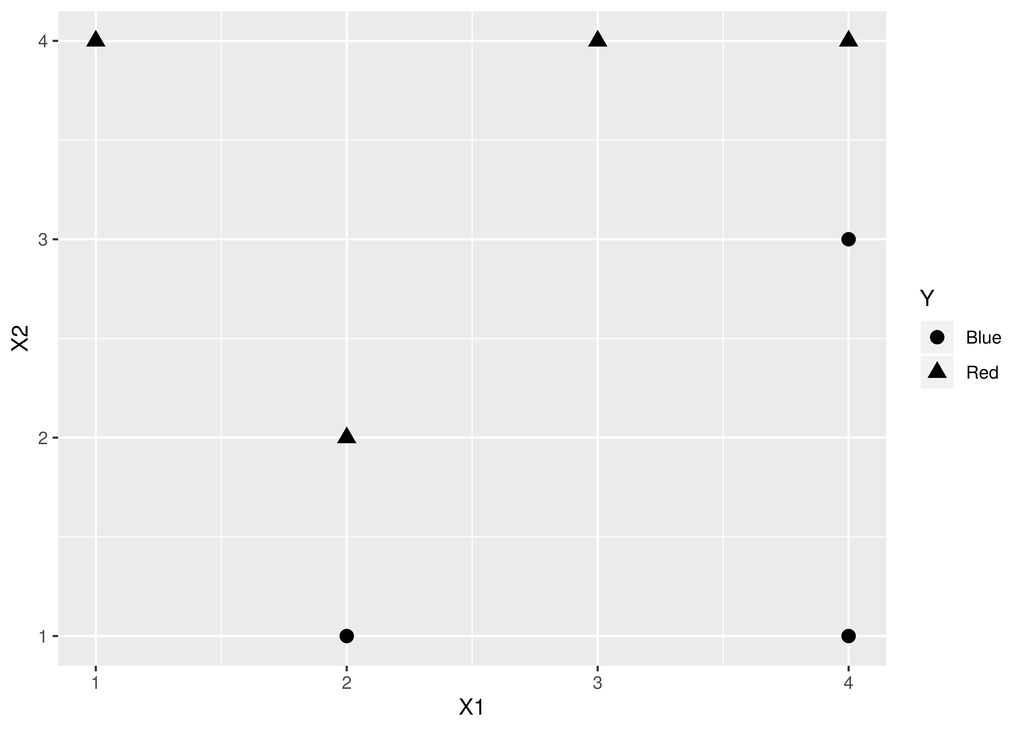

```r
data_3a %>%
    ggplot(aes(X1, X2)) +
    geom_point(aes(shape = Y), size = 3)
```

### b)

**Sketch the optimal separating plane and provide the equation**

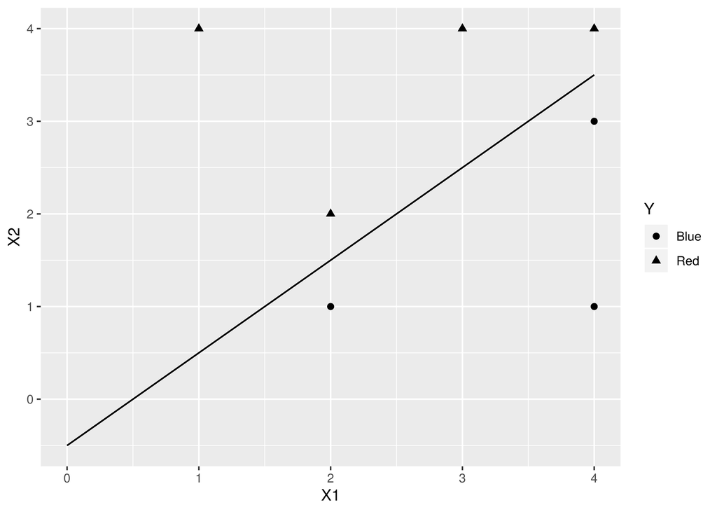

```r
data_3a %>%
    ggplot(aes(X1, X2)) +
    geom_point(aes(shape = Y), size = 2) +
    geom_segment(aes(x = 0, y = -.5, xend = 4, yend = 3.5))
```

### c)

**Describe the classification rule for the MMC.**

The maximal margin classifier is the separating hyperplane that is farthest from the observations.

When the formula is < 0, we assign to Red, when it is > 0 we assign to Blue.

### d)

**On your sketch, indicate the margin for the maximal margin hyperplane.**

The margin is the minimal perpendicular distance from the closest observations to the hyperplane. A rouch sketch is:

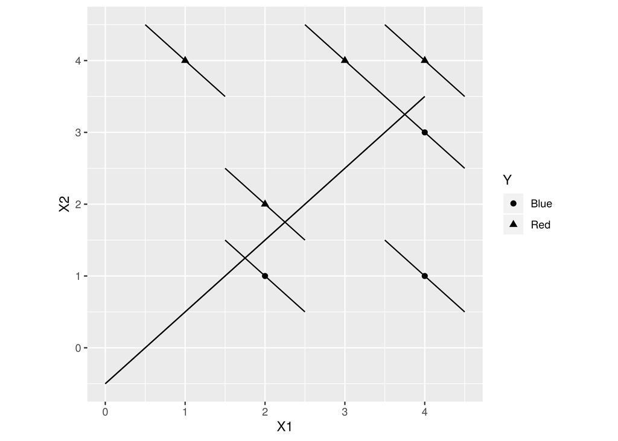

```r
data_3a %>%
    ggplot(aes(X1, X2)) +
    geom_point(aes(shape = Y), size = 2) +
    geom_segment(aes(x = 0, y = -.5, xend = 4, yend = 3.5)) +
    geom_segment(aes(X1 - .5, y = X2 + .5, xend = X1 + .5, yend = X2 - .5)) +
    theme(aspect.ratio = 1)
```

### e)

**Indicate the support vectors for the maximal margin classifier.**

The support vectors look to be $(2,1),\ (2,2),\ (4,3) \text{ and } (4,4)$

### f)

**Argue that a slight movement of the seventh observation would not affect the maximal margin hyperplane.**

The seventh observation is $(4,\ 1)$. This is not a support vector. The maximal margin hyperplane is only determined by the support vectors. This vector can be moved to anywhere outside the margin and it won’t affect the classifier.

If it’s moved inside the current margin, it would affect the classifier.

### g)

**Sketch a hyperplane that is not the optimal separating hyperplane, and provide the equation for this hyperplane.**

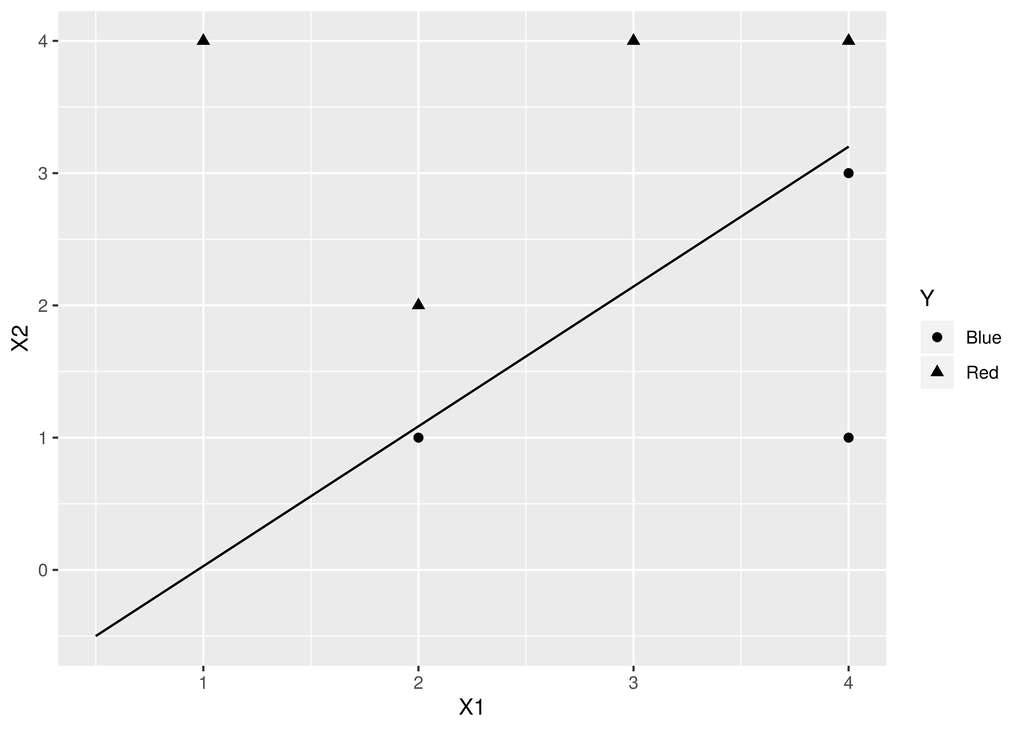

```r
data_3a %>%
    ggplot(aes(X1, X2)) +
    geom_point(aes(shape = Y), size = 2) +
    geom_segment(aes(x = .5, y = -.5, xend = 4, yend = 3.2))
```

### h)

*Draw an additional observation on the plot so that the two classes are no longer separable by a hyperplane.

```r
data_3a <- tibble(
    obs = 1:8,
    X1 = c(3,2,4,1,2,4,4,3),
    X2 = c(4,2,4,4,1,3,1,1),
    Y = as.factor(c('Red', 'Red', 'Red', 'Red', 'Blue', 'Blue', 'Blue', 'Red'))
) %>% ggplot(aes(X1, X2)) +
    geom_point(aes(shape = Y), size = 2) +
    geom_segment(aes(x = 0, y = -.5, xend = 4, yend = 3.5))
```